# Project: Identify Customer Segments

### Under-representation in customer data

- We observe 2 clusters with under-representations, i.e. index `4` and `10`.
- Unsurprisingly, these 2 clusters are very positively correlated in **PC1**, i.e. poorness, direct opposite of our over-representation
- We also see that they are both negatively correlated to **PC2**, i.e. degree of elderly, it would make sense since younger generations would not prefer mail orders since they would be ordering things online
- Cluster index 10 has a higher emphasis over **PC3**, where females tend not to be customers of the company

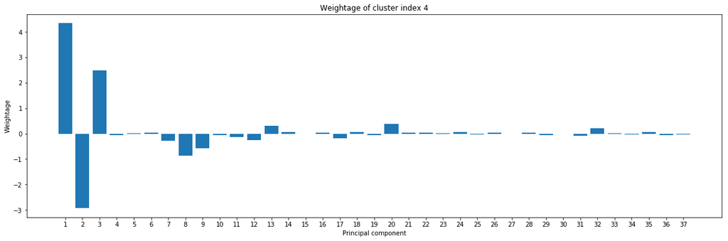

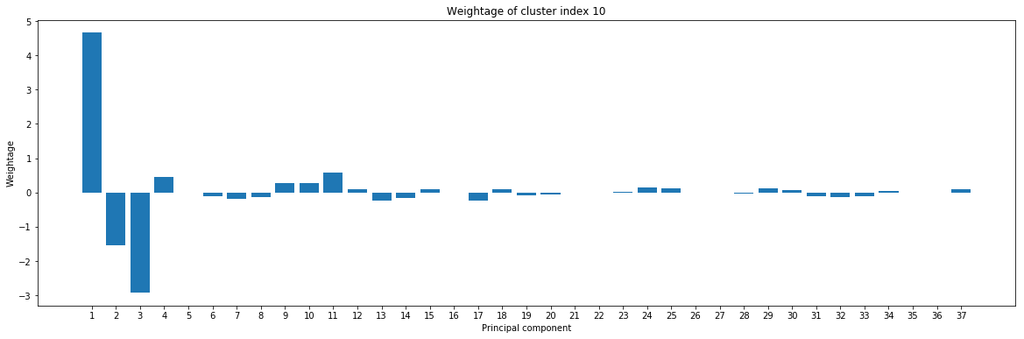

```python
# What kinds of people are part of a cluster that is underrepresented in the
# customer data compared to the general population?
cluster_feature_importances(4, final_k_means.cluster_centers_)
cluster_feature_importances(10, final_k_means.cluster_centers_)
```

### Discussion 3.3: Compare Customer Data to Demographics Data

- Based on our analysis above, the mail-order service tends to favour wealthier individuals and people belonging in higher social circles. It is not heavily preferred by the younger generation as undestandably due to prevalence of online shopping.
- Interesting findings include:
  1. Majority of customers clump into cluster index 5, which are predominantly males who are avantgarde
  2. Another cluster in index 6 suggest predominantly elderly female customers
  3. Cluster index 8 suggest that the mail order service is indifferent on whether the individual's opinions (mainstream or avantgarde)
- Cluster indexes 4 and 10 suggest that customers who are poorer, younger are less likely to use the service

> Congratulations on making it this far in the project! Before you finish, make sure to check through the entire notebook from top to bottom to make sure that your analysis follows a logical flow and all of your findings are documented in **Discussion** cells. Once you've checked over all of your work, you should export the notebook as an HTML document to submit for evaluation. You can do this from the menu, navigating to **File -> Download as -> HTML (.html)**. You will submit both that document and this notebook for your project submission.